# Lecture 1 Time Series and Forecasting

## What is “Time Series”?

Data sampled *in order, over time*.

Regular sampling:

- annual: once per year
- monthly: once per month
- quarterly: once every three months
- weekly, daily, etc

Irregular sampling (not covered)

## What is “Time Series”? Example

Monthly time series of gold price (USD/oz):

```
         Jan     Feb     Mar     Apr
2024 2053.25 2048.05 2214.35 2307.00
         May     Jun     Jul     Aug
2024 2348.25 2330.90 2426.30 2513.35
         Sep     Oct     Nov     Dec
2024 2629.95 2734.15 2651.05 2609.10
```

## What is “Time Series”? Example

Time series plot:

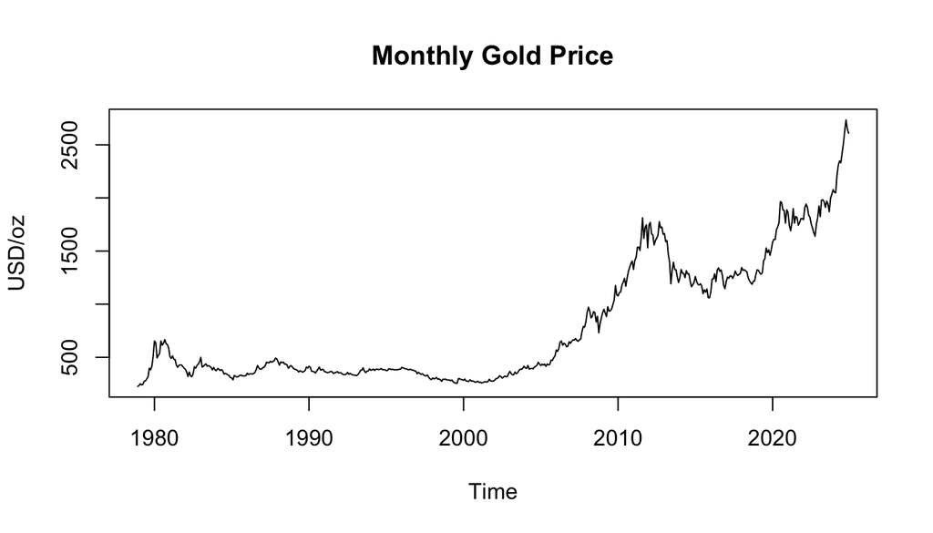

## What is time series “sampling”?

- Concept of a “representative sample” from a “population” is unclear for time series.
- “Sample path”: a time series plot
- “Population” : imagine all possible sample paths that might have occurred if time were re-run repeatedly.

## What is time series “sampling”?

[figure not shown]

## What is time series “sampling”?

[figure not shown]

## What is time series “sampling”?

[figure not shown]

## What is time series “sampling”?

[figure not shown]

## What is time series “sampling”?

[figure not shown]

## What is time series “sampling”?

[figure not shown]

## What is time series “sampling”?

[figure not shown]

## What is time series “sampling”?

[figure not shown]

## What is time series “sampling”?

[figure not shown]

## What is time series “sampling”?

[figure not shown]

## What is time series “sampling”?

[figure not shown]

## What is time series “sampling”?

[figure not shown]

## What is time series “sampling”?

[figure not shown]

## What is time series “sampling”?

[figure not shown]

## What is time series “sampling”?

[figure not shown]

## What is time series “sampling”?

[figure not shown]

## What is time series “sampling”?

[figure not shown]

## Dependence over time

Cross section samples often have observations drawn *independently* from a population.

Time series exhibit *dependence* across time.

(Both a challenge and an opportunity!)

## Dependence over time

Cross section samples often have observations drawn *independently* from a population.

Time series exhibit *dependence* across time.

Eg. dependence between events of

- today and tomorrow
- this month and next month
- this year and next year
- etc

## Dependence over time, example

Dependence can produce a “smooth” plot:

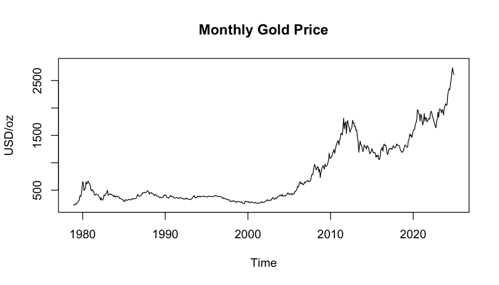

## Lack of Dependence over time, example

A more “random” looking plot:

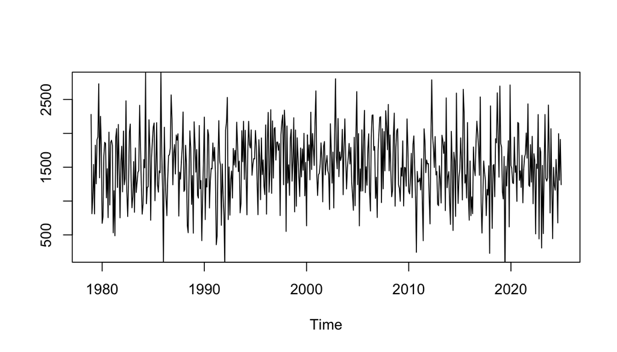

## Dependence over time

Dependence can induce patterns.

Eg:

- smooth swings
- trend (upwards or downwards) over time
- oscillations
- seasonality
- etc

## Dependence over time

Dependence can induce patterns.

Patterns can be *modelled* to produce forecasts.

*Models* include:

- regression
- ARIMA
- Vector Autoregression
- etc

## Forecasting Steps

- Define forecasting problem
- Collect relevant data
- Estimate plausible models for the data
- Evaluate in-sample fit
- Calculate and evaluate forecasts

$${\textbf{Application: Forecasting Retail Sales}}$$

## Example: Retail Sales

- Retail sales are considered a key indicator of the health of an economy.
- Data from Australian Bureau of Statistics, sampled monthly, April 1982 to September 2024.

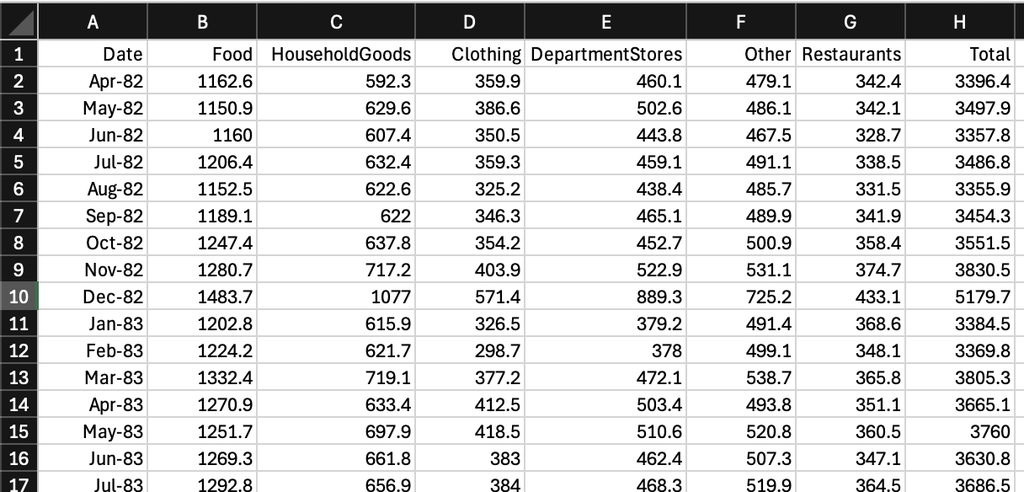

## The ${\color{Apricot}{\textsf{ts}}}$ object

```r
dt <- read.csv("RetailSales.csv")
print(head(dt[c("Food", "Clothing", "Total")]))
```

```
    Food Clothing  Total
1 1162.6    359.9 3396.4
2 1150.9    386.6 3497.9
3 1160.0    350.5 3357.8
4 1206.4    359.3 3486.8
5 1152.5    325.2 3355.9
6 1189.1    346.3 3454.3
```

## The ${\color{Apricot}{\textsf{ts}}}$ object

```r
Retail_m <- ts(dt$Total, frequency=12,
          start=c(1982,4), end=c(2024,9))
print(Retail_m)
```

```
         Jan     Feb     Mar     Apr     May
1982                          3396.4  3497.9
1983  3384.5  3369.8  3805.3  3665.1  3760.0
1984  3698.5  3733.2  4010.9  3788.4  4242.3
1985  4130.0  3856.8  4196.9  4228.9  4739.1
1986  4674.9  4294.1  4528.0  4729.0  5261.9
1987  5065.3  4679.8  4993.0  5166.0  5386.3
1988  5304.4  5226.8  5729.7  5527.3  5787.8
1989  5980.3  5574.1  6299.0  6075.7  6437.8
1990  6511.6  6031.0  6749.3  6476.1  6947.9
1991  6837.2  6284.6  6837.9  6709.5  7191.7
1992  7305.3  6848.2  7164.6  7435.5  7551.4
1993  7455.9  6833.0  7497.4  7539.8  7675.2
1994  7730.6  7295.2  8240.1  7775.5  8061.2
1995  8268.3  7750.3  8656.9  8514.5  8860.4
```

[output cut: 117 more lines]

## The ${\color{Apricot}{\textsf{ts}}}$ object

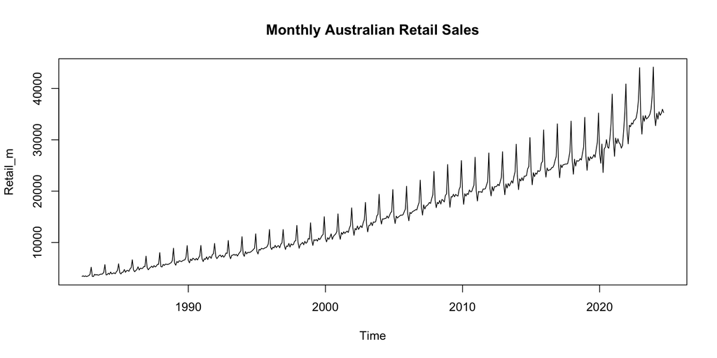

```r
Retail_m <- ts(dt$Total, frequency=12,
          start=c(1982,4), end=c(2024,9))
plot(Retail_m, main="Monthly Australian Retail Sales")
```

## ${\color{Apricot}{\textsf{aggregate}}}$ : change frequency

```r
Retail_m <- ts(dt$Total, frequency=12,
               start=c(1982,4), end=c(2024,9))
Retail_q <- aggregate(Retail_m, FUN=sum,
                      nfrequency=4)
print(Retail_q)
```

```
         Qtr1     Qtr2     Qtr3     Qtr4
1982           10252.1  10297.0  12561.7
1983  10559.6  11055.9  11326.2  13774.5
1984  11442.6  11902.8  11975.5  14678.6
1985  12183.7  13158.3  13461.2  16590.9
1986  13497.0  14628.7  14875.5  17948.6
1987  14738.1  15671.2  16126.4  19511.8
1988  16260.9  17054.3  17456.3  21422.5
1989  17853.4  18890.9  19289.4  23154.1
1990  19291.9  20182.9  20074.0  23819.6
1991  19959.7  20576.1  21307.8  25242.5
1992  21318.1  22167.6  22012.3  26212.7
1993  21786.3  22722.9  22801.1  27563.4
1994  23265.9  23893.8  24709.9  29229.2
1995  24675.5  26142.8  26722.7  31467.4
```

[output cut: 29 more lines]

## Quarters

- Qtr1 : Jan, Feb, Mar (“March quarter”)
- Qtr2 : Apr, May, Jun (“June quarter”)
- Qtr3 : Jul, Aug, Sep (“September quarter”)
- Qtr4 : Oct, Nov, Dec (“December quarter”)

## ${\color{Apricot}{\textsf{log}}}$ : a “stabilising” transformation

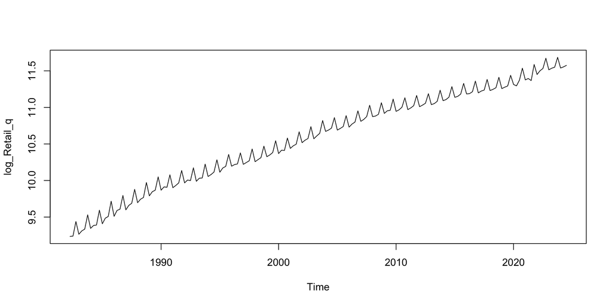

```r
log_Retail_q <- log(Retail_q)
plot(log_Retail_q)
```

## Sample period

We will use observations from 2000 to 2018 to forecast retail sales for 2019.

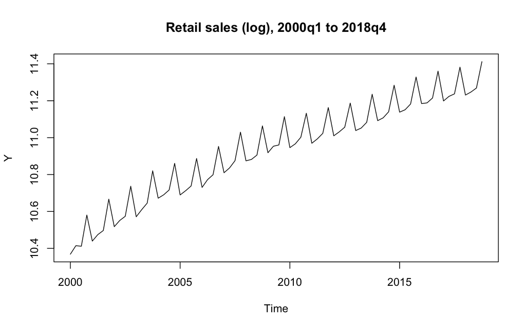

```r
Y <- window(log_Retail_q, start=c(2000,1),
                          end=c(2018,4))
plot(Y, main="Retail sales (log), 2000q1 to 2018q4")
```

## Sample period

We will use observations from 2000 to 2018 to forecast retail sales for 2019.

Why?

- Pre-covid time
- 2019 data is available for *forecast evaluation*

## Forecasting Steps

- Define forecasting problem

## Forecasting Steps

- Define forecasting problem  
  Forecast retail sales for the four quarters of 2019 using data available up to end of 2018.

## Forecasting Steps

- Define forecasting problem  
  Forecast retail sales for the four quarters of 2019 using data available up to end of 2018.
- Collect relevant data

## Forecasting Steps

- Define forecasting problem  
  Forecast retail sales for the four quarters of 2019 using data available up to end of 2018.
- Collect relevant data  
  We have quarterly retail sales for 2000-2018.

## Forecasting Steps

- Define forecasting problem  
  Forecast retail sales for the four quarters of 2019 using data available up to end of 2018.
- Collect relevant data  
  We have quarterly retail sales for 2000-2018.
- Estimate plausible models for the data

## Forecasting Steps

- Define forecasting problem  
  Forecast retail sales for the four quarters of 2019 using data available up to end of 2018.
- Collect relevant data  
  We have quarterly retail sales for 2000-2018.
- Estimate plausible models for the data
- Evaluate in-sample fit
- Calculate and evaluate forecasts

## Plausible models?

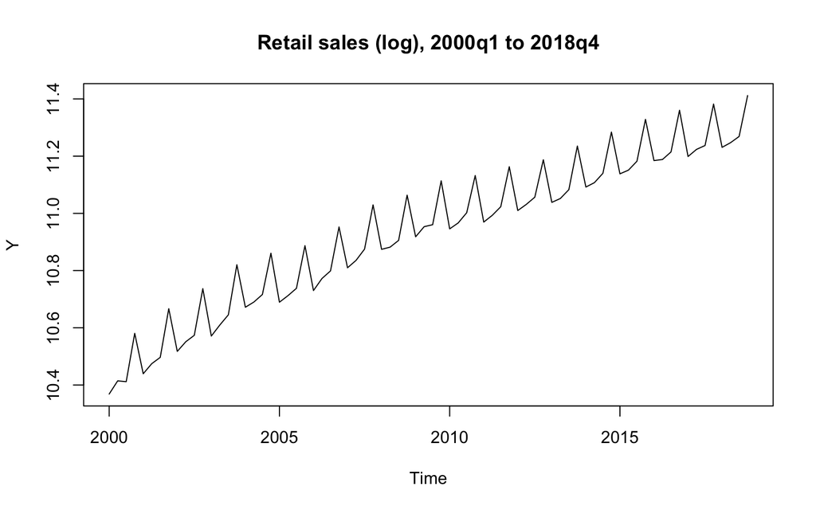

Two obvious features:

- increasing time trend
- seasonal pattern